# Project 5

Creating data from digital sources

Japekam Singh Dang

## Part A

For Part A of this project, I explored the global health metrics provided by the World Health Organization (WHO). I chose this topic because I find it fascinating to see how health trends and challenges vary around the world. The WHO’s data is incredibly detailed and reliable, making it perfect for exploring important issues in global health. Plus, understanding these metrics can really help in shaping effective public health strategies. It was quite interesting yet sad to see a big disparity amongst developed and non developed regions of the world.

```r
library(tidyverse)
library(rvest)

# My data context is the global health metrics provided by the WHO
# Information from webpages that might be useful to scrape includes country profiles, health indicators, and regional health statistics.

# The website I chose to scrape data from is the World Health Organization (WHO) data collection tools page.
# URL: https://www.who.int/data/data-collection-tools/score/country-profiles
# This site allows scraping as it doesn't prohibit it in its robots.txt file and terms/conditions for data use. So it is appropriate for webscraping

# Assign the URL of the webpage to scrape
url <- "https://www.who.int/data/data-collection-tools/score/country-profiles"

# Read the HTML content from the webpage
page <- read_html(url)

# Scrape the main heading from the webpage using the <h1> HTML element
main_heading <- page %>%
  html_elements("h1") %>%
  html_text2()

# Scrape the footer information from the webpage using the <h2> HTML element
footer <- page %>%
  html_elements("h2") %>%
  html_text2()

# Scrape the list of countries linked on the webpage
WHO_countries <- page %>%
  html_elements(".arrowed-link") %>%
  html_text2()

# Scrape the section headings on the webpage
regions <- page %>%
  html_elements(".section-heading") %>%
  html_text2()

# Clean up the scraped region data by removing any extra characters
regions <- str_remove_all(regions, "\r")

# Output the values of the data objects
main_heading
```

```
## [1] "SCORE country profiles"
```

```r
footer
```

```
## [1] "Contact us"
```

```r
WHO_countries
```

```
##   [1] "Algeria"
##   [2] "Angola"
##   [3] "Benin"
##   [4] "Botswana"
##   [5] "Burkina Faso"
##   [6] "Burundi"
##   [7] "Cabo Verde"
##   [8] "Cameroon"
##   [9] "Central African Republic"
##  [10] "Chad"
##  [11] "Comoros"
##  [12] "Congo"
##  [13] "Côte d'Ivoire"
##  [14] "Democratic Republic of the Congo"
##  [15] "Equatorial Guinea"
```

[output cut: 121 more lines]

```r
regions
```

```
## [1] " Africa"                " Americas"              " Eastern Mediterranean"
## [4] " Europe"                " South-East Asia"       " Western Pacific"
```

## Part B

```r
# Load required libraries
library(tidyverse)
library(rvest)

# Selected minister: Hon. Erica Stanford

# 1. Length of words
# PARA 1: Lots of long & fancy words (e.g., "Conference", "Commonwealth").
# PARA 2: A mix of long and short words, some technical ones too (e.g., "initiative").

# 2. Number of words per sentence or paragraph
# PARA 1: Long & complicated sentences, often over 20 words.
# PARA 2: Shorter sentences but still detailed & paragraph length still being similar.

# 3. Frequency of certain words
# PARA 1: Words related to education and government pop up a lot (e.g., "Minister", "conference").
# PARA 2: Words about period products and schools show up frequently (e.g., "period", "schools").

# 4. Use of certain symbols or punctuation
# PARA 1: Lots of commas, quotes, and periods, so it has a pretty complex structure.
# PARA 2: Similar punctuation signs, with lots of quotes and detailed explanstions.

# URL of the minister's page
url <- "https://www.beehive.govt.nz/minister/hon-erica-stanford"

# Scrape the URLs for each release listed on the minister's page
pages <- read_html(url) %>%
  html_elements(".release__wrapper") %>%
  html_elements("h2") %>%
  html_elements("a") %>%
  html_attr("href") %>%
  paste0("https://www.beehive.govt.nz", .)

page_url <- pages[1]

page <- read_html(page_url)

# Scrape the release title
release_title <- page %>%
  html_element("h1") %>%
  html_text2()

# Scrape the release content
release_content <- page %>%
  html_element(".prose") %>%
  html_text2()

# Function to scrape release title and content
get_release <- function(page_url) {
  Sys.sleep(2)
  # print the page_url so if things go wrong
  # we can see which page caused issues
  print(page_url)
  page <- read_html(page_url)

  release_title <- page %>%
    html_element("h1") %>%
    html_text2()

  release_content <- page %>%
    html_element(".prose") %>%
    html_text2()

  tibble(
    release_title = release_title,
    release_content = release_content
  )
}

# Scrape release data
release_data <- map_df(pages, get_release)

# Data manipulations

# Maximum number of words in any release title
max_num_words_title <- release_data$release_title %>%
  str_count("\\w+") %>%
  max()

# Average number of words in the release content
mean_num_words_content <- release_data$release_content %>%
  str_count("\\w+") %>%
  mean()

# Median sentence length in the release content
median_sentence_length <- release_data$release_content %>%
  str_split("\\.\\s+") %>%
  lengths() %>%
  median()

# Ratio of unique words to total words in the release content
unique_words_ratio <- release_data$release_content %>%
  str_split("\\s+") %>%
  unlist() %>%
  unique() %>%
  length() / sum(str_count(release_data$release_content, "\\w+"))

# Count of the word "future" in various forms in the release content
release_data <- release_data %>%
  mutate(future_word_used_count = str_count(release_data$release_content, "future|Future|FUTURE"))

# Total count of the word "future" across all releases
total_future_word_used_count <- release_data$future_word_used_count %>% sum()
```

### **Maximum Title Length**

```r
max_num_words_title <- release_data$release_title %>%
  str_count("\\w+") %>%
  max()
```

The maximum number of words used in a title was 15

### **Average number of words in releases**

```r
mean_num_words_content <- release_data$release_content %>% str_count("\\w+") %>% mean()
```

The Average number of words in releases was 369.5454545

```r
median_sentence_length <- release_data$release_content %>%
  str_split("\\.\\s+") %>%
  lengths() %>%
  median()
```

### **Ratio of unique words to total words**

```r
unique_words_ratio <- release_data$release_content %>%
  str_split("\\s+") %>%
  unlist() %>%
  unique() %>%
  length() / sum(str_count(release_data$release_content, "\\w+"))
```

The Ratio of unique words to total words in content was 0.2709717

### **Frequency of word Future**

```r
# Count of the word "future" in various forms in the release content
release_data <- release_data %>%
  mutate(future_word_used_count = str_count(release_data$release_content, "future|Future|FUTURE"))

# Total count of the word "future" across all releases
total_future_word_used_count <- release_data$future_word_used_count %>% sum()
```

The Frequency of word Future in content was 9

## Part C

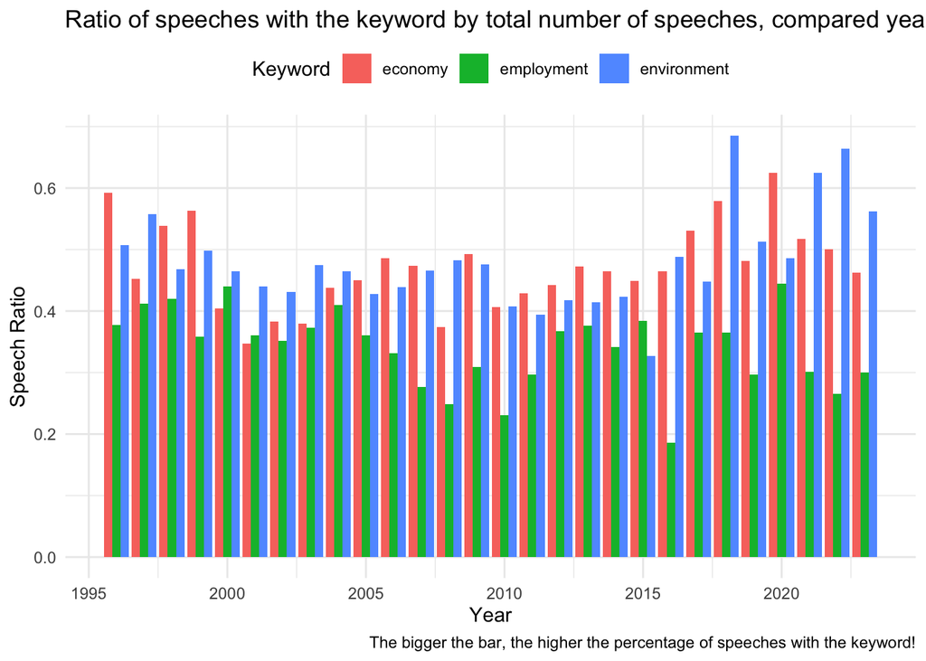

```r
library(tidyverse)
library(rvest)
library(ggplot2)

# Define the keywords to search for in the speeches
keywords <- c("employment", "environment", "economy")

# Scrape and process speech data for the first keyword
search1 <- read_html(paste0("https://datalandscapes.online/scrapeable/speeches.php?search=", keywords[1])) %>%
  html_elements(".speech_summary") %>%
  html_text2() %>%
  tibble(keyword = keywords[1], results = .) %>%
  separate(results, into = c("year", "num_speeches"), sep = "--") %>%
  mutate(num_speeches = parse_number(num_speeches), year = parse_number(year))

# Scrape and process speech data for the second keyword
search2 <- read_html(paste0("https://datalandscapes.online/scrapeable/speeches.php?search=", keywords[2])) %>%
  html_elements(".speech_summary") %>%
  html_text2() %>%
  tibble(keyword = keywords[2], results = .) %>%
  separate(results, into = c("year", "num_speeches"), sep = "--") %>%
  mutate(num_speeches = parse_number(num_speeches), year = parse_number(year))

# Scrape and process speech data for the third keyword
search3 <- read_html(paste0("https://datalandscapes.online/scrapeable/speeches.php?search=", keywords[3])) %>%
  html_elements(".speech_summary") %>%
  html_text2() %>%
  tibble(keyword = keywords[3], results = .) %>%
  separate(results, into = c("year", "num_speeches"), sep = "--") %>%
  mutate(num_speeches = parse_number(num_speeches), year = parse_number(year))

# Combine the individual search data frames into one
combined_search <- bind_rows(search1, search2, search3)

# Load the government speeches data from the Google sheet
speeches_governments <- read_csv("https://docs.google.com/spreadsheets/d/e/2PACX-1vRHTFJcFmsIkjaFUCEwFWASaBOAR4X2Upx66C5Bhgc_WNc2JxxdRbbvyoewmvt_EjNdCNZZzzkENwLg/pub?gid=0&single=true&output=csv")

# Join the combined search data with the government speeches data by year
speech_data <- left_join(combined_search, speeches_governments, by = "year")

# Prepare the data for plotting
plot_data <- speech_data %>%
  group_by(keyword, year) %>%
  summarise(speech_ratio = (num_speeches/total_speeches))

# Create a bargraph using ggplot2
final_plot <- plot_data %>%
  ggplot() +
  geom_bar(aes(x = year, y = speech_ratio, fill = keyword), stat = "identity", position = "dodge") +
  labs(title = "Ratio of speeches with the keyword by total number of speeches, compared yearly",
       caption = "The bigger the bar, the higher the percentage of speeches with the keyword!",
       x = "Year",
       y = "Speech Ratio",
       fill = "Keyword") +
  theme_minimal() +
  theme(legend.position = "top")

final_plot
```

The bargraph shows how often certain keywords (“employment”, “environment”, “economy”) popped up in speeches each year compared to the total number of speeches, showcasing trends in the focus of speeches over time.

## Learning Reflection

This module taught me some crucial skills like web scraping and combining data from different tables. I got a good grasp on the basics of web scraping through the various parts of this project. Although I’m not an expert yet, I feel comfortable scraping simple websites ( of course that permit it). For instance, in Part A, delving into the World Health Organization’s data helped me grasp the basics of web scraping. It was fascinating to see how I could extract valuable information like country profiles and health statistics. Moving on to Part B, analyzing Hon. Erica Stanford’s releases was a bit challenging, but it really helped me understand how to deal with technical terms and varying content lengths. Finally, in Part C, diving into government speeches to find keywords like “employment” was an intriguing exercise that deepened my understanding of data analysis. Overall, it was quite a great learning experience.

## Self Review

I would say that I have really learnt the meaning of data analysis through this course. I did a course before namely Stats 201 which gave me a fair amount of background of R, so I did not struggle with coding part. My favorite part of this course was creating bar graphs and plots in module 4. Overall, I also learnt some basic syntax of SQL, which might be very helpful in future. I also learnt how to communicate with shareholders because creating cool insights is one thing, but making those insights heard is other. My least favourite part of this course was doing some silly mistakes in my projects and losing marks for that. I enjoyed my overall progress in the course. Hopefully, I will keep my journey going!! PS - As a class rep, I also learnt some important skills like leadership and communication. :)